# Messing with

- Two Relationshops (Inheritance)
  - Is a
  - Has a
- "Has-a" Relationship.  
  Through Base and Dervied Class or also called Parent and Child Relationship
- "Is-a" Relationsip One class is inside another class
- Access Specifiers (private, protected, public) That is how visible or connected is the Parent (members and method/functions) from the Child, and visa versa.

  Between Parent and Child, only protected and public. What is private to parent, can only be used by parent.

  $$ \newcommand\T{\Rule{0pt}{1em}{.3em}} \begin{array}{|r|r|r|r|r|r|r|r|r|r|} \hline \T&Private\T&Protected\T&Public \\\hline \text{Inside Class}\T&\Large\color{\green}{\unicode{10003}}\T&\Large\color{\green}{\unicode{10003}}\T&\Large\color{\green}{\unicode{10003}} \\\hline \text{Inside Derived Class}\T&\Large\color{\red}{\unicode{10008}}\T&\Large\color{\green}{\unicode{10003}}\T&\Large\color{\green}{\unicode{10003}} \\\hline \text{On Object - Eg. inside main}\T&\Large\color{\red}{\unicode{10008}}\T&\Large\color{\red}{\unicode{10008}}\T&\Large\color{\green}{\unicode{10003}} \\\hline \end{array} $$

Between parent and child:

The Derive class, inherits from the Base class. And object is where you call it from outside the class.

- Types of Inheritance
- Virual Base classes for multiple inheritance

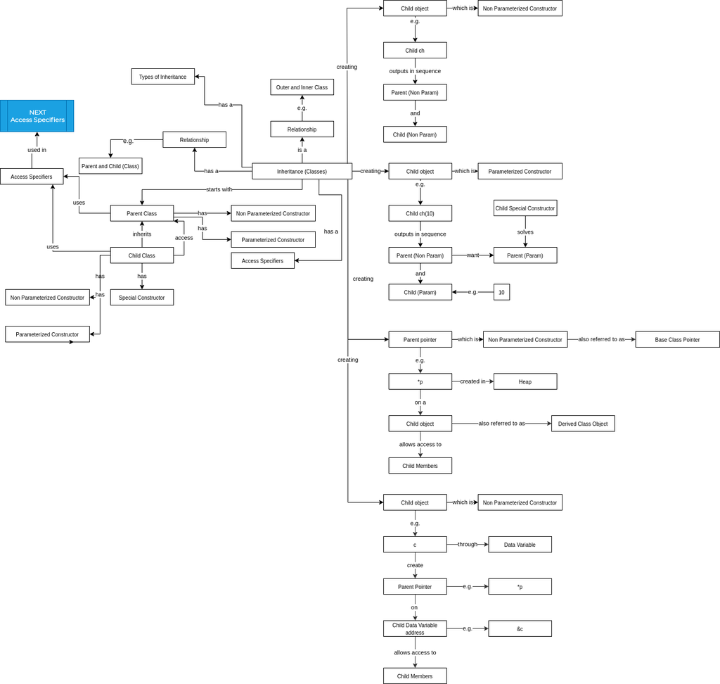

```python
#include <iostream>
#include <climits>
#include <math.h>
#define INSERTION_OPERATOR operator<<
#define EXTRACTION_OPERATOR operator>>
#define ADDITION_OPERATOR operator+
#define SUBTRACT_OPERATOR operator-
using namespace std;
```

## Definition of Inheritance

```python
class Parent{
private:
    int a;
protected:
    int b;
public:
    int c;

public:

    Parent(){
       cout<<"Non Param Parent"<<endl;
    }


    Parent(int n){
        cout<<"Param Parent:"<<n<<endl;
    }
};

class Child:Parent{
public:

    Child(){
       cout<<"Non Param Child"<<endl;
    }


    Child(int n){
        cout<<"Param Child:"<<n<<endl;
    }

    Child(int a, int b):Parent(a){
       cout<<"Param Child (Special):"<<a<<" "<<b<<endl;

    }
};
```

## Calling Child Class (Non Parameterized)

Sequence Output

1. Parent (Non Param)
2. Child ((Non Param)

```python
Child d;
```

```
Non Param Parent
Non Param Child
```

## Calling Child Class (Parameterized)

Sequence Output

1. Parent (Non Param)
2. Child (Param)

So parent non param is run first again, but then the child param is run.

```python
Child d_1(10);
```

```
Non Param Parent
Param Child:10
```

## Calling Child Class (Parameterized) (But want Parent Param first)

From above we saw parent non param, when child param is rum. But we want sequece as follows

```
Param Parent:10
Param Child:10
```

We need a special Constructor in Child Class for this, since how will be identify which `10` belongs to which Constructor

(see in Class above)

```python
Child d_2(10,20);
```

```
Param Parent:10
Param Child (Special):10 20
```